# Risk Factor Analysis

## Outcome Variable

**Outcome Variable:** s03rec24

## Predictor Variables

**Intervention Variable:** sex

**Adjustment Set:**

unadjusted

## Stratifying Variables

The analysis was stratified on these variable(s):

- studyid
- country

## Data Summary

| studyid | country | A | n | nA | nAY0 | nAY1 |
| --- | --- | --- | --- | --- | --- | --- |
| ki0047075b-MAL-ED | BANGLADESH | Female | 247 | 128 | 125 | 3 |
| ki0047075b-MAL-ED | BANGLADESH | Male | 247 | 119 | 114 | 5 |
| ki0047075b-MAL-ED | BRAZIL | Female | 223 | 108 | 97 | 11 |
| ki0047075b-MAL-ED | BRAZIL | Male | 223 | 115 | 108 | 7 |
| ki0047075b-MAL-ED | INDIA | Female | 246 | 135 | 128 | 7 |
| ki0047075b-MAL-ED | INDIA | Male | 246 | 111 | 105 | 6 |
| ki0047075b-MAL-ED | NEPAL | Female | 238 | 110 | 108 | 2 |
| ki0047075b-MAL-ED | NEPAL | Male | 238 | 128 | 119 | 9 |
| ki0047075b-MAL-ED | PERU | Female | 284 | 133 | 126 | 7 |
| ki0047075b-MAL-ED | PERU | Male | 284 | 151 | 139 | 12 |
| ki0047075b-MAL-ED | SOUTH AFRICA | Female | 302 | 152 | 140 | 12 |
| ki0047075b-MAL-ED | SOUTH AFRICA | Male | 302 | 150 | 143 | 7 |
| ki0047075b-MAL-ED | TANZANIA, UNITED REPUBLIC OF | Female | 253 | 128 | 127 | 1 |
| ki0047075b-MAL-ED | TANZANIA, UNITED REPUBLIC OF | Male | 253 | 125 | 125 | 0 |
| ki1000108-CMC-V-BCS-2002 | INDIA | Female | 370 | 185 | 175 | 10 |
| ki1000108-CMC-V-BCS-2002 | INDIA | Male | 370 | 185 | 178 | 7 |
| ki1000108-IRC | INDIA | Female | 410 | 185 | 175 | 10 |
| ki1000108-IRC | INDIA | Male | 410 | 225 | 207 | 18 |
| ki1000109-EE | PAKISTAN | Female | 175 | 96 | 96 | 0 |
| ki1000109-EE | PAKISTAN | Male | 175 | 79 | 79 | 0 |
| ki1000109-ResPak | PAKISTAN | Female | 166 | 77 | 77 | 0 |
| ki1000109-ResPak | PAKISTAN | Male | 166 | 89 | 89 | 0 |
| ki1017093b-PROVIDE | BANGLADESH | Female | 690 | 330 | 319 | 11 |
| ki1017093b-PROVIDE | BANGLADESH | Male | 690 | 360 | 349 | 11 |
| ki1066203-TanzaniaChild2 | TANZANIA, UNITED REPUBLIC OF | Female | 2276 | 1145 | 1143 | 2 |
| ki1066203-TanzaniaChild2 | TANZANIA, UNITED REPUBLIC OF | Male | 2276 | 1131 | 1131 | 0 |
| ki1101329-Keneba | GAMBIA | Female | 2468 | 1182 | 1152 | 30 |
| ki1101329-Keneba | GAMBIA | Male | 2468 | 1286 | 1236 | 50 |
| ki1113344-GMS-Nepal | NEPAL | Female | 594 | 284 | 277 | 7 |
| ki1113344-GMS-Nepal | NEPAL | Male | 594 | 310 | 302 | 8 |
| ki1114097-CMIN | BANGLADESH | Female | 259 | 113 | 109 | 4 |
| ki1114097-CMIN | BANGLADESH | Male | 259 | 146 | 139 | 7 |
| ki1114097-CMIN | PERU | Female | 738 | 344 | 344 | 0 |
| ki1114097-CMIN | PERU | Male | 738 | 394 | 393 | 1 |
| ki1114097-CONTENT | PERU | Female | 214 | 106 | 103 | 3 |
| ki1114097-CONTENT | PERU | Male | 214 | 108 | 97 | 11 |

The following strata were considered:

- studyid: ki0047075b-MAL-ED, country: BANGLADESH
- studyid: ki0047075b-MAL-ED, country: BRAZIL
- studyid: ki0047075b-MAL-ED, country: INDIA
- studyid: ki0047075b-MAL-ED, country: NEPAL
- studyid: ki0047075b-MAL-ED, country: PERU
- studyid: ki0047075b-MAL-ED, country: SOUTH AFRICA
- studyid: ki0047075b-MAL-ED, country: TANZANIA, UNITED REPUBLIC OF
- studyid: ki1000108-CMC-V-BCS-2002, country: INDIA
- studyid: ki1000108-IRC, country: INDIA
- studyid: ki1000109-EE, country: PAKISTAN
- studyid: ki1000109-ResPak, country: PAKISTAN
- studyid: ki1017093b-PROVIDE, country: BANGLADESH
- studyid: ki1066203-TanzaniaChild2, country: TANZANIA, UNITED REPUBLIC OF
- studyid: ki1101329-Keneba, country: GAMBIA
- studyid: ki1113344-GMS-Nepal, country: NEPAL
- studyid: ki1114097-CMIN, country: BANGLADESH
- studyid: ki1114097-CMIN, country: PERU
- studyid: ki1114097-CONTENT, country: PERU

### Dropped Strata

Some strata were dropped due to rare outcomes:

- studyid: ki0047075b-MAL-ED, country: BANGLADESH
- studyid: ki0047075b-MAL-ED, country: NEPAL
- studyid: ki0047075b-MAL-ED, country: TANZANIA, UNITED REPUBLIC OF
- studyid: ki1000109-EE, country: PAKISTAN
- studyid: ki1000109-ResPak, country: PAKISTAN
- studyid: ki1066203-TanzaniaChild2, country: TANZANIA, UNITED REPUBLIC OF
- studyid: ki1114097-CMIN, country: BANGLADESH
- studyid: ki1114097-CMIN, country: PERU
- studyid: ki1114097-CONTENT, country: PERU

## Methods Detail

We’re interested in the causal parameters $E[Y_a]$ for all values of $a \in \mathcal{A}$. These parameters represent the mean outcome if, possibly contrary to fact, we intervened to set all units to have $A=a$. Under the randomization and positivity assumptions, these are identified by the statistical parameters $\psi_a=E_W[E_{Y|A,W}(Y|A=a,W)]$. In addition, we’re interested in the mean of $Y$, $E[Y]$ under no intervention (the observed mean). We will estimate these parameters by using SuperLearner to fit the relevant likelihood factors – $E_{Y|A,W}(Y|A=a,W)$ and $p(A=a|W)$, and then updating our likelihood fit using a joint TMLE.

For unadjusted analyses ($W=\{\}$), initial likelihoods were estimated using Lrnr_glm to estimate the simple $E(Y|A)$ and Lrnr_mean to estimate $p(A)$. For adjusted analyses, a small library containing Lrnr_glmnet, Lrnr_xgboost, and Lrnr_mean was used.

Having estimated these parameters, we will then use the delta method to estimate relative risks and attributable risks relative to a prespecified baseline level of $A$.

# Results Detail

## Results Plots

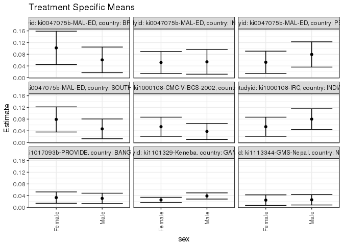

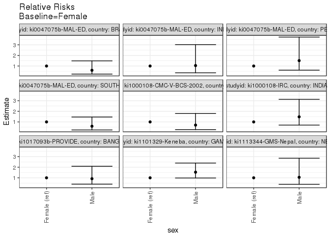

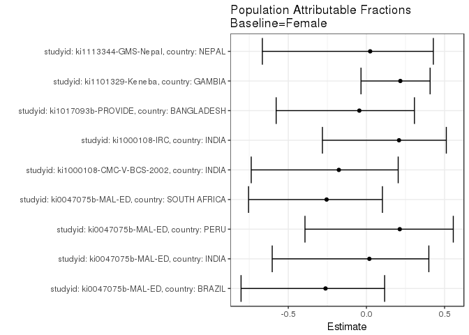

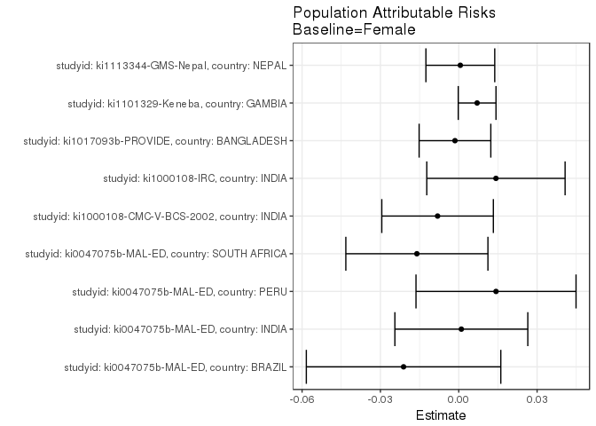

## Results Table

### Parameter: TSM

| studyid | country | intervention_level | baseline_level | estimate | ci_lower | ci_upper |
| --- | --- | --- | --- | --- | --- | --- |
| ki0047075b-MAL-ED | BRAZIL | Female | NA | 0.1018519 | 0.0446815 | 0.1590222 |
| ki0047075b-MAL-ED | BRAZIL | Male | NA | 0.0608696 | 0.0170732 | 0.1046659 |
| ki0047075b-MAL-ED | INDIA | Female | NA | 0.0518519 | 0.0143730 | 0.0893307 |
| ki0047075b-MAL-ED | INDIA | Male | NA | 0.0540541 | 0.0119020 | 0.0962061 |
| ki0047075b-MAL-ED | PERU | Female | NA | 0.0526316 | 0.0146152 | 0.0906480 |
| ki0047075b-MAL-ED | PERU | Male | NA | 0.0794702 | 0.0362540 | 0.1226864 |
| ki0047075b-MAL-ED | SOUTH AFRICA | Female | NA | 0.0789474 | 0.0360078 | 0.1218869 |
| ki0047075b-MAL-ED | SOUTH AFRICA | Male | NA | 0.0466667 | 0.0128564 | 0.0804769 |
| ki1000108-CMC-V-BCS-2002 | INDIA | Female | NA | 0.0540541 | 0.0214255 | 0.0866826 |
| ki1000108-CMC-V-BCS-2002 | INDIA | Male | NA | 0.0378378 | 0.0103059 | 0.0653698 |
| ki1000108-IRC | INDIA | Female | NA | 0.0540541 | 0.0214299 | 0.0866782 |
| ki1000108-IRC | INDIA | Male | NA | 0.0800000 | 0.0445084 | 0.1154916 |
| ki1017093b-PROVIDE | BANGLADESH | Female | NA | 0.0333333 | 0.0139520 | 0.0527147 |
| ki1017093b-PROVIDE | BANGLADESH | Male | NA | 0.0305556 | 0.0127638 | 0.0483473 |
| ki1101329-Keneba | GAMBIA | Female | NA | 0.0253807 | 0.0164127 | 0.0343487 |
| ki1101329-Keneba | GAMBIA | Male | NA | 0.0388802 | 0.0283128 | 0.0494477 |
| ki1113344-GMS-Nepal | NEPAL | Female | NA | 0.0246479 | 0.0066000 | 0.0426957 |
| ki1113344-GMS-Nepal | NEPAL | Male | NA | 0.0258065 | 0.0081412 | 0.0434717 |

### Parameter: E(Y)

| studyid | country | intervention_level | baseline_level | estimate | ci_lower | ci_upper |
| --- | --- | --- | --- | --- | --- | --- |
| ki0047075b-MAL-ED | BRAZIL | NA | NA | 0.0807175 | 0.0448848 | 0.1165502 |
| ki0047075b-MAL-ED | INDIA | NA | NA | 0.0528455 | 0.0248312 | 0.0808598 |
| ki0047075b-MAL-ED | PERU | NA | NA | 0.0669014 | 0.0377918 | 0.0960110 |
| ki0047075b-MAL-ED | SOUTH AFRICA | NA | NA | 0.0629139 | 0.0354838 | 0.0903440 |
| ki1000108-CMC-V-BCS-2002 | INDIA | NA | NA | 0.0459459 | 0.0245838 | 0.0673081 |
| ki1000108-IRC | INDIA | NA | NA | 0.0682927 | 0.0438464 | 0.0927390 |
| ki1017093b-PROVIDE | BANGLADESH | NA | NA | 0.0318841 | 0.0187654 | 0.0450027 |
| ki1101329-Keneba | GAMBIA | NA | NA | 0.0324149 | 0.0254265 | 0.0394034 |
| ki1113344-GMS-Nepal | NEPAL | NA | NA | 0.0252525 | 0.0126250 | 0.0378801 |

### Parameter: RR

| studyid | country | intervention_level | baseline_level | estimate | ci_lower | ci_upper |
| --- | --- | --- | --- | --- | --- | --- |
| ki0047075b-MAL-ED | BRAZIL | Female | Female | 1.0000000 | 1.0000000 | 1.000000 |
| ki0047075b-MAL-ED | BRAZIL | Male | Female | 0.5976285 | 0.2399450 | 1.488507 |
| ki0047075b-MAL-ED | INDIA | Female | Female | 1.0000000 | 1.0000000 | 1.000000 |
| ki0047075b-MAL-ED | INDIA | Male | Female | 1.0424710 | 0.3599889 | 3.018832 |
| ki0047075b-MAL-ED | PERU | Female | Female | 1.0000000 | 1.0000000 | 1.000000 |
| ki0047075b-MAL-ED | PERU | Male | Female | 1.5099338 | 0.6113613 | 3.729219 |
| ki0047075b-MAL-ED | SOUTH AFRICA | Female | Female | 1.0000000 | 1.0000000 | 1.000000 |
| ki0047075b-MAL-ED | SOUTH AFRICA | Male | Female | 0.5911111 | 0.2389033 | 1.462568 |
| ki1000108-CMC-V-BCS-2002 | INDIA | Female | Female | 1.0000000 | 1.0000000 | 1.000000 |
| ki1000108-CMC-V-BCS-2002 | INDIA | Male | Female | 0.7000000 | 0.2719624 | 1.801719 |
| ki1000108-IRC | INDIA | Female | Female | 1.0000000 | 1.0000000 | 1.000000 |
| ki1000108-IRC | INDIA | Male | Female | 1.4800000 | 0.6997599 | 3.130216 |
| ki1017093b-PROVIDE | BANGLADESH | Female | Female | 1.0000000 | 1.0000000 | 1.000000 |
| ki1017093b-PROVIDE | BANGLADESH | Male | Female | 0.9166667 | 0.4025715 | 2.087276 |
| ki1101329-Keneba | GAMBIA | Female | Female | 1.0000000 | 1.0000000 | 1.000000 |
| ki1101329-Keneba | GAMBIA | Male | Female | 1.5318818 | 0.9809001 | 2.392356 |
| ki1113344-GMS-Nepal | NEPAL | Female | Female | 1.0000000 | 1.0000000 | 1.000000 |
| ki1113344-GMS-Nepal | NEPAL | Male | Female | 1.0470046 | 0.3842616 | 2.852793 |

### Parameter: PAR

| studyid | country | intervention_level | baseline_level | estimate | ci_lower | ci_upper |
| --- | --- | --- | --- | --- | --- | --- |
| ki0047075b-MAL-ED | BRAZIL | Female | NA | -0.0211344 | -0.0583712 | 0.0161025 |
| ki0047075b-MAL-ED | INDIA | Female | NA | 0.0009937 | -0.0244575 | 0.0264448 |
| ki0047075b-MAL-ED | PERU | Female | NA | 0.0142698 | -0.0163728 | 0.0449124 |
| ki0047075b-MAL-ED | SOUTH AFRICA | Female | NA | -0.0160335 | -0.0432401 | 0.0111732 |
| ki1000108-CMC-V-BCS-2002 | INDIA | Female | NA | -0.0081081 | -0.0294703 | 0.0132540 |
| ki1000108-IRC | INDIA | Female | NA | 0.0142386 | -0.0122465 | 0.0407237 |
| ki1017093b-PROVIDE | BANGLADESH | Female | NA | -0.0014493 | -0.0151763 | 0.0122777 |
| ki1101329-Keneba | GAMBIA | Female | NA | 0.0070342 | -0.0001927 | 0.0142611 |
| ki1113344-GMS-Nepal | NEPAL | Female | NA | 0.0006046 | -0.0125754 | 0.0137846 |

### Parameter: PAF

| studyid | country | intervention_level | baseline_level | estimate | ci_lower | ci_upper |
| --- | --- | --- | --- | --- | --- | --- |
| ki0047075b-MAL-ED | BRAZIL | Female | NA | -0.2618313 | -0.8022114 | 0.1165197 |
| ki0047075b-MAL-ED | INDIA | Female | NA | 0.0188034 | -0.6028241 | 0.3993435 |
| ki0047075b-MAL-ED | PERU | Female | NA | 0.2132964 | -0.3932007 | 0.5557693 |
| ki0047075b-MAL-ED | SOUTH AFRICA | Female | NA | -0.2548476 | -0.7542463 | 0.1023823 |
| ki1000108-CMC-V-BCS-2002 | INDIA | Female | NA | -0.1764706 | -0.7371124 | 0.2032277 |
| ki1000108-IRC | INDIA | Female | NA | 0.2084942 | -0.2815483 | 0.5111527 |
| ki1017093b-PROVIDE | BANGLADESH | Female | NA | -0.0454545 | -0.5775928 | 0.3071880 |
| ki1101329-Keneba | GAMBIA | Female | NA | 0.2170051 | -0.0346936 | 0.4074758 |
| ki1113344-GMS-Nepal | NEPAL | Female | NA | 0.0239437 | -0.6658956 | 0.4281238 |